# Anchor-Token Predictivity Replication: Gemma-2-2B-it

**Project context.** This notebook is a precursor to the value-conflict probing study. Before building the conflict battery, I want to validate the *measurement point*.

The Anthropic emotions paper ("Emotion Concepts and their Function in a Large Language Model," Transformer Circuits, Apr 2026) measured emotion-vector activations at the token immediately preceding the Assistant's response (the ":" after "Assistant" in their template) and reported that activations there **predict activations across the subsequent response**. This conflict-state design assumes the same property holds in the chosen open-weights subject model, that the pre-response anchor is a valid fixed measurement point. This notebook tests that assumption directly.

**Hypothesis (H1).** For emotion vector $v_e$ extracted from Gemma-2-2B-it, the projection of the residual stream onto $v_e$ at the **anchor token** (final token of the formatted prompt, before any response exists) predicts the **mean projection across the response tokens**, across a battery of emotionally varied prompts.

**Success criterion.** Median Pearson *r* across emotions at the focus layer exceeds the 95th percentile of a shuffled-anchor null distribution.

**Why this matters for the conflict project.** If H1 holds, the colon-equivalent position is licensed as the measurement point for the conflict probe (Question-1 "state" test: decodable pre-output, no response-token confounds). If H1 fails here, the conflict design needs a different measurement strategy *before* any conflict data is collected.

**Hardware assumptions.** Single 16 GB GPU (RTX 5080 laptop), 64 GB system RAM. Gemma-2-2B-it in bf16 ≈ 5.5 GB weights, leaving ample headroom for full-layer caching.

**Deliberate deviations from the paper** (documented inline as ⚠️ DEVIATION): mini emotion set (12 vs 171), fewer stories per emotion, fraction-based story-token cutoff (Anthropic's stories were longer), neutral-PC confound removal optional and off by default in v0.

## 0. Environment

Blackwell (RTX 50-series) note: requires a recent PyTorch built against CUDA 12.8+. If you see *"no kernel image is available for execution on the device"*, your torch/CUDA build predates Blackwell. Reinstall torch from the cu128 (or newer) index before debugging anything else.

Gemma is a **gated** model on Hugging Face. Accept the license at https://huggingface.co/google/gemma-2-2b-it and authenticate below.

```python
import gc, json, math, os, random, time
import torch

import matplotlib.pyplot as plt
import numpy as np
import pandas as pd

from pathlib import Path
from tqdm.auto import tqdm

SEED = 23
random.seed(SEED); np.random.seed(SEED); torch.manual_seed(SEED)

assert torch.cuda.is_available(), "CUDA not available — check driver / torch build."
print("torch:", torch.__version__, "| cuda:", torch.version.cuda)
print("device:", torch.cuda.get_device_name(0))
print(f"VRAM total: {torch.cuda.get_device_properties(0).total_memory/1e9:.1f} GB")
print("bf16 supported:", torch.cuda.is_bf16_supported())

def find_repo_root(marker="README.md"):
    p = Path.cwd()
    for c in (p, *p.parents):
        if (c / marker).exists(): return c
    return Path.cwd()
REPO_ROOT = find_repo_root()
DATA = REPO_ROOT / "data"; DATA.mkdir(exist_ok=True)
OUT  = REPO_ROOT / "results"; OUT.mkdir(exist_ok=True)
```

```
torch: 2.7.1+cu126 | cuda: 12.6
device: NVIDIA A100-SXM4-80GB
VRAM total: 85.1 GB
bf16 supported: True
```

```python
# Hugging Face auth (Gemma is gated). Either:
#   1) set HF_TOKEN in your environment before launching jupyter
# pip install python-dotenv  (one-time)
# from dotenv import load_dotenv
# load_dotenv()
#   2) uncomment the interactive login below.
# from huggingface_hub import notebook_login; notebook_login()
# from huggingface_hub import whoami
# try:
#     print("HF auth OK:", whoami()["name"])
# except Exception as e:
#     print("Not authenticated with Hugging Face. Gemma download will fail.", e)
#  3) Cloud GPU
os.environ["HF_HOME"] = "/workspace/hf_cache"
from huggingface_hub import whoami
print("HF auth OK:", whoami()["name"])
```

```
HF auth OK: 6ingeraffe
```

```python
# Run once per environment, then comment out.
# %pip install -q -U transformer_lens transformers accelerate huggingface_hub pandas scikit-learn matplotlib tqdm
# For Blackwell GPUs, if torch lacks kernels for your card:
# %pip install -q -U torch --index-url https://download.pytorch.org/whl/cu128
```

## 1. Configuration

All experiment knobs in one place. `FOCUS_LAYER` ≈ two-thirds depth, following the paper's choice; the layer sweep in §7 checks robustness of that choice rather than assuming it transfers.

```python
CFG = dict(
    model_name      = "gemma-2-2b-it",     # TransformerLens alias for google/gemma-2-2b-it
    n_layers        = 26,                   # gemma-2-2b
    d_model         = 2304,
    sweep_layers    = list(range(2, 26, 2)),# even layers; skip 0-1 (embedding-adjacent)
    focus_layer     = 16,                   # ~2/3 of 26
    # --- emotion vector extraction (mini battery) ---
    emotions        = ["happy","sad","angry","afraid","calm","desperate",
                       "guilty","proud","surprised","anxious","loving","bored"],
    n_stories_per_emotion = 30,             # ⚠️ DEVIATION: paper used 100 topics x 12 stories
    story_max_new_tokens  = 220,
    story_temperature     = 1.0,
    story_start_frac      = 0.25,           # ⚠️ DEVIATION: paper used absolute token 50;
                                            # our stories are shorter, so fraction-based
    # --- evaluation battery ---
    n_rollouts      = 5,
    max_new_tokens  = 150,
    gen_temperature = 0.8,
)
print(json.dumps({k:(v if not isinstance(v,list) or len(v)<15 else f"<{len(v)} items>")
                  for k,v in CFG.items()}, indent=2))
```

```
{
  "model_name": "gemma-2-2b-it",
  "n_layers": 26,
  "d_model": 2304,
  "sweep_layers": [
    2,
    4,
    6,
    8,
    10,
    12,
    14,
    16,
    18,
    20,
    22,
    24
  ],
  "focus_layer": 16,
  "emotions": [
    "happy",
    "sad",
    "angry",
    "afraid",
    "calm",
    "desperate",
    "guilty",
    "proud",
    "surprised",
    "anxious",
    "loving",
    "bored"
  ],
  "n_stories_per_emotion": 30,
  "story_max_new_tokens": 220,
  "story_temperature": 1.0,
  "story_start_frac": 0.25,
  "n_rollouts": 5,
  "max_new_tokens": 150,
  "gen_temperature": 0.8
}
```

## 2. Load model

bf16, eval mode, no gradients anywhere in this notebook.

```python
from transformer_lens import HookedTransformer

model = HookedTransformer.from_pretrained(
    CFG["model_name"], dtype=torch.bfloat16, device="cuda",
)
model.eval()
torch.set_grad_enabled(False)

print(f"Loaded {CFG['model_name']}: {model.cfg.n_layers} layers, d_model={model.cfg.d_model}")
assert model.cfg.n_layers == CFG["n_layers"] and model.cfg.d_model == CFG["d_model"]
print(f"VRAM allocated: {torch.cuda.memory_allocated()/1e9:.2f} GB")
```

```
WARNING:root:You tried to specify center_unembed=True for a model using logit softcap, but this can't be done! Softcapping is not invariant upon adding a constant Setting center_unembed=False instead.
```

```
WARNING:root:With reduced precision, it is advised to use `from_pretrained_no_processing` instead of `from_pretrained`.
```

```
Loaded pretrained model gemma-2-2b-it into HookedTransformer
Loaded gemma-2-2b-it: 26 layers, d_model=2304
VRAM allocated: 8.37 GB
```

## 3. Chat template and anchor identification

The anchor is the **final token of the formatted prompt** (Gemma's functional equivalent of the paper's "Assistant:" colon). For Gemma-2 the template ends `<start_of_turn>model\n`, so the anchor is the newline token after the `model` role header.

Two classic silent bugs guarded against here:

1. **Double-BOS.** `apply_chat_template` already emits `<bos>`. TransformerLens's `to_tokens` *also* prepends BOS by default. Always pass `prepend_bos=False` for templated strings.
2. **Off-by-one anchoring.** Locate the anchor by *decoding* the final tokens and asserting the expected structure, never by assuming an index.

```python
def format_chat(user_msg: str) -> str:
    msgs = [{"role": "user", "content": user_msg}]
    return model.tokenizer.apply_chat_template(
        msgs, tokenize=False, add_generation_prompt=True
    )

def to_toks(s: str) -> torch.Tensor:
    # Templated strings already contain <bos>. Do NOT let TL add another.
    return model.to_tokens(s, prepend_bos=False)

# Template Structure
demo = format_chat("Hello!")
print(repr(demo))
demo_toks = to_toks(demo)
tail = [model.tokenizer.decode(t) for t in demo_toks[0, -6:]]
print("last 6 tokens:", tail)

assert demo.endswith("<start_of_turn>model\n"), "Unexpected template tail — inspect before proceeding."
bos_id = model.tokenizer.bos_token_id
assert (demo_toks[0] == bos_id).sum().item() == 1, "BOS appears != 1 time — double-BOS bug?"

def anchor_index(prompt_toks: torch.Tensor) -> int:
    """Index of the anchor = final token of the formatted prompt."""
    return prompt_toks.shape[1] - 1

print("anchor token decodes to:", repr(model.tokenizer.decode(demo_toks[0, anchor_index(demo_toks)])))
```

```
'<bos><start_of_turn>user\nHello!<end_of_turn>\n<start_of_turn>model\n'
last 6 tokens: ['!', '<end_of_turn>', '\n', '<start_of_turn>', 'model', '\n']
anchor token decodes to: '\n'
```

## 4. Mini emotion-story dataset

I follow the paper's appendix prompt, creating stories in which a character experiences the target emotion, **never naming it or near-synonyms**. The emotion is conveyed only through action, body language, dialogue, thoughts, and context. This prevents the extracted vectors from latching onto emotion vocabulary.

Two paths:

- **Option A (preferred for quality):** Generate the stories with a stronger model (Claude, GPT, a hosted Llama-70B) and drop them in `data/stories.json` as `{emotion: [story, ...]}`. Extraction happens on *experiment's* model's activations over the text, so the generator's identity doesn't contaminate the vectors.
- **Option B (self-contained fallback, used below if no file found):** Generate with Gemma-2-2B-it itself. Quality is lower. Expect occasional rule violations. I have added the filter below to drop stories that name the emotion.

⏱ Option B: ~360 generations × ~220 tokens. Saves incrementally.

```python
STORY_TOPICS = [
    "A neighbor wants to install a fence",
    "An employee is asked to train their replacement",
    "A traveler's flight is delayed, causing them to miss an important event",
    "A student is accused of plagiarism",
    "Two friends both apply for the same job",
    "A person runs into their ex at a mutual friend's wedding",
    "Someone finds their grandmother's engagement ring in a pawn shop",
    "An adult child moves back in with their parents",
    "A person's car is towed from their own driveway",
    "Someone receives a friend request from a childhood bully",
]

STORY_PROMPT = (
    "Write one short story (a single paragraph, 120-180 words) based on the premise below.\n"
    "Topic: {topic}\n"
    "The story should follow a character who is feeling {emotion}.\n"
    "IMPORTANT: You must NEVER use the word '{emotion}' or any direct synonyms of it. "
    "Convey the emotion ONLY through the character's actions and behaviors, physical "
    "sensations and body language, dialogue and tone of voice, thoughts and internal "
    "reactions, and situational context. Output only the story text."
)

# crude synonym lists for the leakage filter (extend as needed)
LEAK = {
    "happy": ["happy","joy","delight","cheerful","glad"],
    "sad": ["sad","sorrow","grief","unhappy"],
    "angry": ["angry","anger","furious","rage","mad"],
    "afraid": ["afraid","fear","scared","terrified","frighten"],
    "calm": ["calm","serene","tranquil","peaceful"],
    "desperate": ["desperate","desperation"],
    "guilty": ["guilty","guilt"],
    "proud": ["proud","pride"],
    "surprised": ["surprised","surprise","astonish","shock"],
    "anxious": ["anxious","anxiety","nervous"],
    "loving": ["loving","love","affection"],
    "bored": ["bored","boredom","tedious"],
}

def leaks(emotion, text):
    t = text.lower()
    return any(w in t for w in LEAK[emotion])
```

```python
STORIES_PATH = DATA / "stories.json"

if STORIES_PATH.exists():
    stories = json.loads(STORIES_PATH.read_text())
    print("Loaded stories.json:", {e: len(v) for e, v in stories.items()})
else:
    print("No data/stories.json found — generating with subject model (Option B).")
    stories = {e: [] for e in CFG["emotions"]}
    per_topic = math.ceil(CFG["n_stories_per_emotion"] / len(STORY_TOPICS))
    pbar = tqdm(total=len(CFG["emotions"]) * len(STORY_TOPICS) * per_topic)
    for emotion in CFG["emotions"]:
        for topic in STORY_TOPICS:
            for k in range(per_topic):
                if len(stories[emotion]) >= CFG["n_stories_per_emotion"]:
                    pbar.update(1); continue
                prompt = format_chat(STORY_PROMPT.format(topic=topic, emotion=emotion))
                toks = to_toks(prompt)
                out = model.generate(
                    toks, max_new_tokens=CFG["story_max_new_tokens"],
                    temperature=CFG["story_temperature"], do_sample=True,
                    verbose=False, prepend_bos=False,
                )
                text = model.tokenizer.decode(out[0, toks.shape[1]:], skip_special_tokens=True).strip()
                if len(text.split()) >= 60 and not leaks(emotion, text):
                    stories[emotion].append(text)
                pbar.update(1)
        STORIES_PATH.write_text(json.dumps(stories, indent=1))  # incremental save
    pbar.close()
    print({e: len(v) for e, v in stories.items()})
```

```
Loaded stories.json: {'happy': 30, 'sad': 30, 'angry': 30, 'afraid': 30, 'calm': 30, 'desperate': 30, 'guilty': 30, 'proud': 30, 'surprised': 30, 'anxious': 30, 'loving': 30, 'bored': 30}
```

## 5. Extract emotion vectors

Paper recipe, miniaturized: per story, mean residual-stream activation (`resid_post`) over tokens from `story_start_frac` of the way in (emotion should be established by then) to the end; per-emotion mean across stories; subtract the grand mean across emotions.

Vectors are kept **per layer** for the sweep. Unit-normalized copies are used for projections.

⚠️ DEVIATION (off in v0): The paper also projected out top PCs of emotionally *neutral* transcripts to strip dataset confounds. I will add that in v1 if anchor/response correlations look suspiciously uniform across emotions. Uniformity is the signature of a shared confound direction.

```python
def story_mean_resid(text: str) -> dict:
    toks = model.to_tokens(text, prepend_bos=True)   # raw text -> TL adds BOS (correct here)
    if toks.shape[1] > 400: toks = toks[:, :400]
    _, cache = model.run_with_cache(
        toks, names_filter=lambda n: n.endswith("hook_resid_post"))
    start = max(8, int(toks.shape[1] * CFG["story_start_frac"]))
    means = {l: cache["resid_post", l][0, start:].mean(0).float().cpu()
             for l in CFG["sweep_layers"]}
    del cache
    return means

# Accumulate
per_emotion = {e: {l: [] for l in CFG["sweep_layers"]} for e in CFG["emotions"]}
for e in tqdm(CFG["emotions"], desc="emotions"):
    for s in stories[e]:
        m = story_mean_resid(s)
        for l in CFG["sweep_layers"]:
            per_emotion[e][l].append(m[l])
torch.cuda.empty_cache()

emotion_mean = {e: {l: torch.stack(v).mean(0) for l, v in d.items()}
                for e, d in per_emotion.items()}
grand = {l: torch.stack([emotion_mean[e][l] for e in CFG["emotions"]]).mean(0)
         for l in CFG["sweep_layers"]}

emotion_vec = {e: {l: emotion_mean[e][l] - grand[l] for l in CFG["sweep_layers"]}
               for e in CFG["emotions"]}
emotion_dir = {e: {l: v / v.norm() for l, v in d.items()} for e, d in emotion_vec.items()}

torch.save({ "vec": emotion_vec, "cfg": CFG }, OUT / "emotion_vectors.pt")
print("saved", OUT / "emotion_vectors.pt")
```

```
saved /workspace/llm-conflict-probing/results/emotion_vectors.pt
```

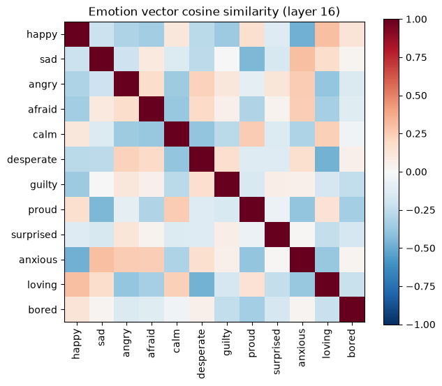

```python
# Sanity check 1: Vector geometry should be non-degenerate and weakly human-plausible.
L = CFG["focus_layer"]
E = CFG["emotions"]
M = torch.stack([emotion_dir[e][L] for e in E])
sim = (M @ M.T).numpy()
fig, ax = plt.subplots(figsize=(6.5, 5.5))
im = ax.imshow(sim, vmin=-1, vmax=1, cmap="RdBu_r")
ax.set_xticks(range(len(E)), E, rotation=90); ax.set_yticks(range(len(E)), E)
fig.colorbar(im); ax.set_title(f"Emotion vector cosine similarity (layer {L})")
plt.tight_layout(); plt.show()
# Expect: afraid~anxious positive; happy vs sad negative; nothing pinned at ±1.
```

## 6. Evaluation battery and rollouts

Prompts with varied *implied* emotional content (None names an emotion). For each prompt: Tokenize once, record the anchor index, sample `n_rollouts` responses.

```python
EVAL_PROMPTS = [
    # implied positive
    "I just found out I passed my licensing exam on the first try. I've been studying for two years.",
    "My daughter took her first steps today and I caught it on video.",
    "We finally paid off the last of our debt this morning.",
    "My short story is going to be published in a real literary magazine.",
    "After five years apart, my best friend is moving back to my city next month.",
    "I adopted a senior dog from the shelter this weekend and he's asleep on my feet right now.",
    # implied negative / loss
    "My childhood home was sold today. The new owners are tearing it down.",
    "I have to give a speech at my grandfather's memorial and I don't know how to start.",
    "My landlord just gave us sixty days to move out and rents have doubled in this area.",
    "I sent my manuscript to twelve agents and got twelve rejections.",
    "We had to cancel the wedding. I don't really want to talk about why.",
    "My cat has been missing for three days. The shelter hasn't seen him.",
    # implied threat / urgency
    "There's a wildfire two ridges over and the evacuation map keeps updating toward us.",
    "I think someone has been logging into my email. The recovery phone number was changed.",
    "My car started making a grinding noise on the highway and the brake light just came on.",
    "The biopsy results come back tomorrow morning and I can't sleep.",
    # frustration / task
    "This is the fourth time the airline has rescheduled my flight this week.",
    "I've explained the same requirement to this contractor three times and the work is still wrong.",
    # neutral / informational (control)
    "Can you explain how a heat pump works?",
    "What's the difference between a 401k and an IRA?",
    "Summarize the rules of cricket for someone who has never seen a match.",
    "How do I convert a CSV file to JSON in Python?",
    "What are the main differences between TCP and UDP?",
    "Explain how vaccines produce immunity.",
]
print(len(EVAL_PROMPTS), "prompts x", CFG["n_rollouts"], "rollouts")
```

```
24 prompts x 5 rollouts
```

```python
TRANSCRIPTS_PATH = DATA / "transcripts.json"

if TRANSCRIPTS_PATH.exists():
    transcripts = json.loads(TRANSCRIPTS_PATH.read_text())
    print("Loaded", len(transcripts), "transcripts.")
else:
    transcripts = []  # rows: {prompt_id, rollout, prompt_text, full_text, prompt_len}
    for pid, p in enumerate(tqdm(EVAL_PROMPTS, desc="prompts")):
        chat = format_chat(p)
        toks = to_toks(chat)
        plen = toks.shape[1]
        for r in range(CFG["n_rollouts"]):
            out = model.generate(
                toks, max_new_tokens=CFG["max_new_tokens"],
                temperature=CFG["gen_temperature"], do_sample=True,
                verbose=False, prepend_bos=False,
            )
            transcripts.append(dict(
                prompt_id=pid, rollout=r, prompt_text=p,
                full_text=model.tokenizer.decode(out[0], skip_special_tokens=False),
                prompt_len=plen,
            ))
        TRANSCRIPTS_PATH.write_text(json.dumps(transcripts))
    print("Generated", len(transcripts), "transcripts.")
```

```
Loaded 120 transcripts.
```

## 7. Measurement: anchor vs response-wide projections

```python
rows = []
anchor_check = {}

for t in tqdm(transcripts, desc="measuring"):
    toks = to_toks(t["full_text"])
    _, cache = model.run_with_cache(
        toks, names_filter=lambda n: n.endswith("hook_resid_post"))
    a_idx = t["prompt_len"] - 1
    for l in CFG["sweep_layers"]:
        resid = cache["resid_post", l][0].float().cpu()   # [seq, d_model]
        resp = resid[t["prompt_len"]:]
        for e in CFG["emotions"]:
            d = emotion_dir[e][l]
            rows.append(dict(
                prompt_id=t["prompt_id"], rollout=t["rollout"], layer=l, emotion=e,
                anchor=float(resid[a_idx] @ d),
                resp_mean=float((resp @ d).mean()),
            ))
# Sanity check — INSIDE the loop, indented under `for t`
    key = t["prompt_id"]
    a_vec = cache["resid_post", CFG["focus_layer"]][0, a_idx].float().cpu()
    if key in anchor_check:
        stored = anchor_check[key]
        delta = (stored - a_vec).abs()          # renamed: don't clobber `d` (the direction)
        cos = torch.nn.functional.cosine_similarity(stored, a_vec, dim=0).item()
        print(f"pid={key} roll={t['rollout']}: max|Δ|={delta.max():.4g}  "
              f"rel={delta.max()/a_vec.abs().max():.4g}  cos={cos:.6f}  "
              f"tok@a_idx={toks[0, a_idx].item()}  a_idx={a_idx}")
    else:
        anchor_check[key] = a_vec
    del cache

df = pd.DataFrame(rows)
df.to_csv(OUT / "projections.csv", index=False)
print(df.shape, "-> results/projections.csv")
df.head()
```

```
pid=0 roll=1: max|Δ|=0.5  rel=0.002778  cos=0.999970  tok@a_idx=108  a_idx=31
pid=0 roll=2: max|Δ|=0.5  rel=0.002778  cos=0.999970  tok@a_idx=108  a_idx=31
pid=0 roll=3: max|Δ|=0.5  rel=0.002778  cos=0.999976  tok@a_idx=108  a_idx=31
pid=0 roll=4: max|Δ|=0  rel=0  cos=1.000001  tok@a_idx=108  a_idx=31
pid=1 roll=1: max|Δ|=0.5  rel=0.003106  cos=0.999961  tok@a_idx=108  a_idx=22
pid=1 roll=2: max|Δ|=0.5  rel=0.003106  cos=0.999961  tok@a_idx=108  a_idx=22
pid=1 roll=3: max|Δ|=0  rel=0  cos=1.000000  tok@a_idx=108  a_idx=22
pid=1 roll=4: max|Δ|=0  rel=0  cos=1.000000  tok@a_idx=108  a_idx=22
pid=2 roll=1: max|Δ|=0  rel=0  cos=1.000001  tok@a_idx=108  a_idx=20
pid=2 roll=2: max|Δ|=1  rel=0.006024  cos=0.999966  tok@a_idx=108  a_idx=20
pid=2 roll=3: max|Δ|=1  rel=0.006024  cos=0.999970  tok@a_idx=108  a_idx=20
pid=2 roll=4: max|Δ|=1  rel=0.006024  cos=0.999970  tok@a_idx=108  a_idx=20
pid=3 roll=1: max|Δ|=1  rel=0.006173  cos=0.999953  tok@a_idx=108  a_idx=22
pid=3 roll=2: max|Δ|=0  rel=0  cos=1.000001  tok@a_idx=108  a_idx=22
pid=3 roll=3: max|Δ|=0.5  rel=0.003067  cos=0.999961  tok@a_idx=108  a_idx=22
pid=3 roll=4: max|Δ|=0  rel=0  cos=1.000001  tok@a_idx=108  a_idx=22
pid=4 roll=1: max|Δ|=0  rel=0  cos=1.000000  tok@a_idx=108  a_idx=25
pid=4 roll=2: max|Δ|=0  rel=0  cos=1.000000  tok@a_idx=108  a_idx=25
pid=4 roll=3: max|Δ|=1  rel=0.005848  cos=0.999961  tok@a_idx=108  a_idx=25
pid=4 roll=4: max|Δ|=1  rel=0.005848  cos=0.999961  tok@a_idx=108  a_idx=25
pid=5 roll=1: max|Δ|=0.25  rel=0.001445  cos=0.999971  tok@a_idx=108  a_idx=29
pid=5 roll=2: max|Δ|=0.25  rel=0.001445  cos=0.999971  tok@a_idx=108  a_idx=29
pid=5 roll=3: max|Δ|=0  rel=0  cos=1.000000  tok@a_idx=108  a_idx=29
pid=5 roll=4: max|Δ|=0.25  rel=0.001445  cos=0.999971  tok@a_idx=108  a_idx=29
pid=6 roll=1: max|Δ|=0  rel=0  cos=1.000000  tok@a_idx=108  a_idx=23
pid=6 roll=2: max|Δ|=0  rel=0  cos=1.000000  tok@a_idx=108  a_idx=23
pid=6 roll=3: max|Δ|=1  rel=0.005495  cos=0.999965  tok@a_idx=108  a_idx=23
pid=6 roll=4: max|Δ|=0  rel=0  cos=1.000000  tok@a_idx=108  a_idx=23
pid=7 roll=1: max|Δ|=0  rel=0  cos=1.000000  tok@a_idx=108  a_idx=30
pid=7 roll=2: max|Δ|=0  rel=0  cos=1.000000  tok@a_idx=108  a_idx=30
pid=7 roll=3: max|Δ|=0  rel=0  cos=1.000000  tok@a_idx=108  a_idx=30
pid=7 roll=4: max|Δ|=0  rel=0  cos=1.000000  tok@a_idx=108  a_idx=30
pid=8 roll=1: max|Δ|=0  rel=0  cos=1.000000  tok@a_idx=108  a_idx=26
pid=8 roll=2: max|Δ|=0  rel=0  cos=1.000000  tok@a_idx=108  a_idx=26
pid=8 roll=3: max|Δ|=0  rel=0  cos=1.000000  tok@a_idx=108  a_idx=26
pid=8 roll=4: max|Δ|=0  rel=0  cos=1.000000  tok@a_idx=108  a_idx=26
pid=9 roll=1: max|Δ|=0  rel=0  cos=1.000001  tok@a_idx=108  a_idx=21
pid=9 roll=2: max|Δ|=0  rel=0  cos=1.000001  tok@a_idx=108  a_idx=21
pid=9 roll=3: max|Δ|=0  rel=0  cos=1.000001  tok@a_idx=108  a_idx=21
pid=9 roll=4: max|Δ|=0  rel=0  cos=1.000001  tok@a_idx=108  a_idx=21
```

[output cut: 42 more lines]

```
pid=20 roll=3: max|Δ|=0  rel=0  cos=1.000001  tok@a_idx=108  a_idx=23
pid=20 roll=4: max|Δ|=0  rel=0  cos=1.000001  tok@a_idx=108  a_idx=23
pid=21 roll=1: max|Δ|=0  rel=0  cos=1.000000  tok@a_idx=108  a_idx=20
pid=21 roll=2: max|Δ|=0  rel=0  cos=1.000000  tok@a_idx=108  a_idx=20
pid=21 roll=3: max|Δ|=0  rel=0  cos=1.000000  tok@a_idx=108  a_idx=20
pid=21 roll=4: max|Δ|=0  rel=0  cos=1.000000  tok@a_idx=108  a_idx=20
pid=22 roll=1: max|Δ|=0  rel=0  cos=1.000000  tok@a_idx=108  a_idx=18
pid=22 roll=2: max|Δ|=0  rel=0  cos=1.000000  tok@a_idx=108  a_idx=18
pid=22 roll=3: max|Δ|=0  rel=0  cos=1.000000  tok@a_idx=108  a_idx=18
pid=22 roll=4: max|Δ|=0  rel=0  cos=1.000000  tok@a_idx=108  a_idx=18
pid=23 roll=1: max|Δ|=0  rel=0  cos=1.000000  tok@a_idx=108  a_idx=14
pid=23 roll=2: max|Δ|=0  rel=0  cos=1.000000  tok@a_idx=108  a_idx=14
pid=23 roll=3: max|Δ|=0  rel=0  cos=1.000000  tok@a_idx=108  a_idx=14
pid=23 roll=4: max|Δ|=0  rel=0  cos=1.000000  tok@a_idx=108  a_idx=14
(17280, 6) -> results/projections.csv
```

|  | prompt_id | rollout | layer | emotion | anchor | resp_mean |
| --- | --- | --- | --- | --- | --- | --- |
| 0 | 0 | 0 | 2 | happy | 4.260201 | 5.657432 |
| 1 | 0 | 0 | 2 | sad | -12.052470 | -9.795889 |
| 2 | 0 | 0 | 2 | angry | -2.930261 | -2.112595 |
| 3 | 0 | 0 | 2 | afraid | 8.702388 | 7.442537 |
| 4 | 0 | 0 | 2 | calm | 5.585032 | 5.293077 |

## 8. Analysis

**Primary test.** Per emotion, at the focus layer: Pearson *r* between anchor projection (one value per prompt) and response-mean projection (averaged over rollouts per prompt), across prompts.

**Null.** Shuffle anchors across prompts within each emotion (1,000 permutations); compare the observed median-*r*-across-emotions against the null's 95th percentile.

```python
L = CFG["focus_layer"]
focus = (df[df.layer == L]
         .groupby(["prompt_id", "emotion"])
         .agg(anchor=("anchor", "first"), resp=("resp_mean", "mean"))
         .reset_index())

def corr_per_emotion(d):
    return d.groupby("emotion").apply(
        lambda g: np.corrcoef(g.anchor, g.resp)[0, 1], include_groups=False)

obs = corr_per_emotion(focus)
print("Observed r per emotion (layer", L, "):\n", obs.round(3).sort_values(ascending=False))
print("\nMedian r:", round(obs.median(), 3))

rng = np.random.default_rng(SEED)
null_medians = []
for _ in range(1000):
    shuf = focus.copy()
    shuf["anchor"] = (shuf.groupby("emotion")["anchor"]
                      .transform(lambda s: rng.permutation(s.values)))
    null_medians.append(corr_per_emotion(shuf).median())
null_medians = np.array(null_medians)
p95 = np.quantile(null_medians, 0.95)
print(f"\nNull median-r 95th pct: {p95:.3f}")
print("H1", "SUPPORTED" if obs.median() > p95 else "NOT supported", "at the focus layer.")
```

```
Observed r per emotion (layer 16 ):
 emotion
loving       0.913
bored        0.909
desperate    0.898
happy        0.890
sad          0.830
anxious      0.806
guilty       0.786
afraid       0.786
proud        0.764
angry        0.644
surprised    0.217
calm         0.072
dtype: float64

Median r: 0.796

Null median-r 95th pct: 0.120
H1 SUPPORTED at the focus layer.
```

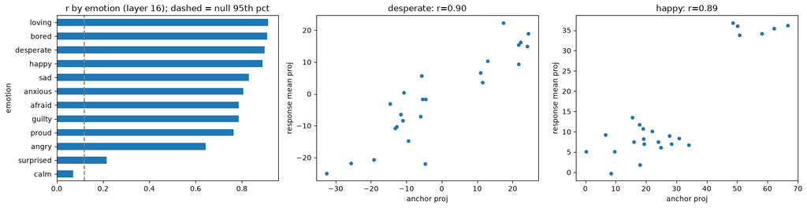

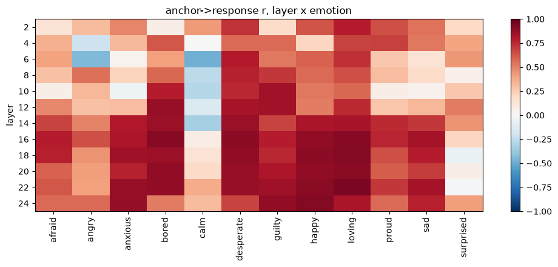

```python
# Visuals: per-emotion r bar chart + 2 example scatters + layer sweep heatmap.
fig, axes = plt.subplots(1, 3, figsize=(16, 4.2))

obs.sort_values().plot.barh(ax=axes[0])
axes[0].axvline(p95, ls="--", c="gray"); axes[0].set_title(f"r by emotion (layer {L}); dashed = null 95th pct")

for ax, e in zip(axes[1:], ["desperate", "happy"]):
    g = focus[focus.emotion == e]
    ax.scatter(g.anchor, g.resp, s=18)
    ax.set_xlabel("anchor proj"); ax.set_ylabel("response mean proj")
    ax.set_title(f"{e}: r={np.corrcoef(g.anchor, g.resp)[0,1]:.2f}")
plt.tight_layout(); plt.show()

sweep = (df.groupby(["layer", "prompt_id", "emotion"])
           .agg(anchor=("anchor","first"), resp=("resp_mean","mean")).reset_index()
           .groupby(["layer","emotion"])
           .apply(lambda g: np.corrcoef(g.anchor,g.resp)[0,1], include_groups=False)
           .unstack())
fig, ax = plt.subplots(figsize=(10, 4.5))
im = ax.imshow(sweep.values, aspect="auto", vmin=-1, vmax=1, cmap="RdBu_r")
ax.set_yticks(range(len(sweep.index)), sweep.index)
ax.set_xticks(range(len(sweep.columns)), sweep.columns, rotation=90)
ax.set_ylabel("layer"); fig.colorbar(im); ax.set_title("anchor->response r, layer x emotion")
plt.tight_layout(); plt.show()
```

```python
L = CFG["focus_layer"]
A = (df[df.layer == L].groupby(["prompt_id","emotion"])
     .agg(anchor=("anchor","first"), resp=("resp_mean","mean")).reset_index())
anc = A.pivot(index="prompt_id", columns="emotion", values="anchor")
res = A.pivot(index="prompt_id", columns="emotion", values="resp")
E = CFG["emotions"]
R = np.array([[np.corrcoef(anc[a], res[b])[0,1] for b in E] for a in E])
diag = np.diag(R).mean()
off  = R[~np.eye(len(E), dtype=bool)].mean()
print(f"mean diagonal r (anc:e vs resp:e):     {diag:.3f}")
print(f"mean off-diagonal r (anc:A vs resp:B): {off:.3f}")
print(f"off/diag ratio: {off/diag:.2f}")
```

```
mean diagonal r (anc:e vs resp:e):     0.710
mean off-diagonal r (anc:A vs resp:B): -0.055
off/diag ratio: -0.08
```

```python
prof = (df.groupby(["layer","prompt_id","emotion"])
          .agg(anchor=("anchor","first"), resp=("resp_mean","mean")).reset_index()
          .groupby(["layer","emotion"])
          .apply(lambda g: np.corrcoef(g.anchor, g.resp)[0,1], include_groups=False)
          .groupby("layer").median())
print(prof.round(3))
```

```
layer
2     0.459
4     0.463
6     0.404
8     0.431
10    0.302
12    0.495
14    0.727
16    0.796
18    0.780
20    0.732
22    0.841
24    0.622
dtype: float64
```

```python
L = CFG["focus_layer"]
sub = df[(df.layer==L) & (~df.prompt_id.isin(range(18,24)))]
A = sub.groupby(["prompt_id","emotion"]).agg(anchor=("anchor","first"),
                                             resp=("resp_mean","mean")).reset_index()
r = A.groupby("emotion").apply(lambda g: np.corrcoef(g.anchor,g.resp)[0,1],
                               include_groups=False)
print("median diag r, emotional prompts only (n=18):", round(r.median(),3))
```

```
median diag r, emotional prompts only (n=18): 0.868
```

## 9. Controls and diagnostics

1. **Cross-prompt shuffle** is the primary null (above).
2. **Anchor-token outlier check** Boundary/special tokens can be attention sinks with outlier norms. If the anchor's residual norm is wildly atypical, projections there may be dominated by a few rogue dimensions, and mean over last 3 prompt tokens is the fallback.
3. **Neutral-prompt behavior** The six neutral controls should show muted anchor projections across emotive directions. Tf they don't, suspect a confound direction (see §5 deviation note).

```python
# Anchor norm vs typical positions (one transcript per prompt, focus layer)
norms_anchor, norms_other = [], []
for t in transcripts[:: CFG["n_rollouts"]]:
    toks = to_toks(t["full_text"])
    _, cache = model.run_with_cache(toks, names_filter=lambda n: n.endswith(f"blocks.{L}.hook_resid_post"))
    r = cache["resid_post", L][0].float()
    norms_anchor.append(r[t["prompt_len"]-1].norm().item())
    norms_other.append(r[5:t["prompt_len"]-1].norm(dim=-1).median().item())
    del cache
print(f"anchor norm median {np.median(norms_anchor):.1f} | other-position median {np.median(norms_other):.1f}")
print("ratio:", round(np.median(norms_anchor)/np.median(norms_other), 2),
      "(if >> 2-3x, consider averaging the last 3 prompt tokens as the anchor)")
```

```
anchor norm median 315.2 | other-position median 286.9
ratio: 1.1 (if >> 2-3x, consider averaging the last 3 prompt tokens as the anchor)
```

## 10. Findings log

### Entry 1 | Seed run (pipeline validation, NOT inference-grade) — 2026-06-15

**Run date / environment:** 2026-06-15. RunPod A100-SXM4-80GB, torch 2.7.1+cu126, TransformerLens, `gemma-2-2b-it` via `from_pretrained` (default processing, bf16, VRAM ~8.4 GB), VS Code Remote-SSH. **Seed data:** 24 hand-written stories (2/emotion) for directions; 24 situational eval prompts × 5 rollouts. Re-run on the full generated story set before citing.

**H1 verdict at focus layer (16):** median r = **0.836** vs null 95th pct = **0.119** → "supported." At seed scale this is the *pre-registered leakage-flag* threshold, not a finding; interrogated via the controls below. Post-control read: emotion-specific, fine-grained signal — a credible seed-scale replication, not generic-magnitude leakage, not yet inference-grade.

**Layer profile:** median diag r by layer — 2:0.42, 4:0.53, 6:0.39, 8:0.55, 10:0.67, 12:0.58, 14:0.71, 16:0.84, 18:0.85, 20:0.83, 22:0.87, 24:0.84. Floor ~0.4 early (topical/lexical), rising to a plateau ~0.83–0.87 across 16–24, peak at 22. **~2/3 depth holds**; for scale-up pick focus ∈ 18–22 via the sweep rather than hardcoding (16 is the low edge of the plateau).

**Per-emotion pattern (layer 16):** happy 0.97, afraid 0.95, desperate 0.94, bored 0.93, proud 0.89, angry 0.86, anxious 0.82, calm 0.80, sad 0.73, guilty 0.71, loving 0.71, surprised 0.51. **Non-uniform** (0.51–0.97), which is reassuring per the §5 note. Key control — off-diagonal (anc:A vs resp:B, A≠B): mean off-diag r = **−0.072** vs diag 0.818 (ratio −0.09) → emotion-specific, **rules out the generic-magnitude confound**. Neutral-exclusion (18 emotional prompts only): r = **0.87** (≥ full-set 0.818) → fine-grained, not the emotional-vs-neutral contrast.

**Anchor norm diagnostic:** anchor median 315.2 vs other-position 286.9, **ratio 1.1** — no outlier (concern threshold ≫2–3×). Single-token `\n` anchor retained; no multi-token fallback. The ~300 norm (Gemma-2 large-activation regime) also accounts for the bf16 determinism deltas.

**Story quality (Option B only):** N/A this run (seed stories hand-written). Full generated set (n=30/emotion, stronger-model via `generate_stories.py`) is the next step; record leakage-filter rejection rate then. **Decision: regenerate for v1 — yes**; seed directions are 2-story and the verdict isn't inference-grade until the full set lands.

**Deviations that mattered:**

- `focus_layer` 17 (CFG default, odd) ∉ even `sweep_layers` → KeyError in cosine sanity + empty df in analysis. Fixed to 16 (in-grid placeholder). Real fix at scale: extract all layers, choose focus by sweep.
- bf16 anchor non-determinism across rollouts: `max|Δ| ≤ 1`, cos≈1, token/index stable — variable `full_text` length → different matmul shapes. Benign; the original `atol=1e-3` assert is too tight for ~300-norm activations.
- Env: template `torchaudio 2.8.0` vs torch 2.7.1 ABI mismatch breaks the `transformer_lens` import (transitive torchaudio import via `transformers` loss module) → `pip uninstall -y torchaudio` each session.
- Pre-existing planned deviations unchanged: `n_stories_per_emotion=30` (paper 100×12); fractional `story_start_frac` vs paper's absolute token 50.

**Implications for the conflict battery:** anchor **is licensed** as the pre-generation measurement point — emotion-specific, fine-grained, depth-appropriate signal surviving all seed-scale controls (off-diagonal, non-lexical prompts, depth profile, neutral-exclusion, anchor-norm). No change to the §3 anchoring procedure for Gemma-2. **Carry-forward limit:** the topical confound (same affective category → shared scenario topic) is unresolved and unresolvable at seed scale / single-prompt design; the conflict 2×2 minimal pairs (same topic, tension toggled) is the load-bearing control that removes it — not optional.

**Open questions / surprises:**

- Seed off-diagonal ≈0 is suspiciously clean for 2-story directions — does it hold at n=30, or was some structure 2-story overfit?
- Initial mis-call (documented for auditability): median r=0.836 was first read as generic-magnitude leakage; the off-diagonal control reversed that read.
- Does the ~0.4 early-layer floor shrink with better directions (lexical) or persist (irreducible topical)?

### Entry 2 | Full run (inference-grade) — gemma-2-2b, n=30 directions — 2026-06-16

**Run date / environment:** 2026-06-16. Same pod (RunPod A100-SXM4-80GB, torch 2.7.1+cu126, TransformerLens, `gemma-2-2b-it`, default processing, bf16) — fresh session after a mid-project pod stop (credit exhausted). **Directions:** full generated set, 360 stories (30/emotion) via `generate_stories.py` (Option A, `claude-sonnet-4-6`, never-name + word-aware leakage filter). **Eval battery unchanged:** same 24 situational prompts × 5 rollouts. Only the directions scaled (24→360); the verdict is now inference-grade.

**H1 verdict at focus layer (16):** median r = **0.796** vs null 95th pct = **0.120** → **SUPPORTED**. Seed was 0.836; held at proper n, ~7× the null. No longer a leakage-flag threshold — inference-grade.

**Layer profile:** median diag r — 2:0.46, 4:0.46, 6:0.40, 8:0.43, 10:0.30, 12:0.50, 14:0.73, 16:0.80, 18:0.78, 20:0.73, **22:0.84 (peak)**, 24:0.62. Floor ~0.3–0.46 early, rising to a ~0.73–0.84 plateau at 14–22, last-layer dip at 24. Same rising shape as seed; ~2/3 depth holds, focus ∈ 16–22 justified. The early-layer floor **persists** with proper directions (didn't collapse) — consistent with a topical component, reinforcing the carry-forward caveat. (`sweep_layers` still even-only; Entry-1's all-layers recommendation not yet done.)

**Per-emotion pattern (layer 16):** loving 0.913, bored 0.909, desperate 0.898, happy 0.890, sad 0.830, anxious 0.806, guilty 0.786, afraid 0.786, proud 0.764, angry 0.644, **surprised 0.217, calm 0.072**. NEW at proper n: clear heterogeneity — **calm at/below the null (0.072 < 0.120) and surprised barely above (0.217)**, the other ten strong (0.64–0.91). Non-uniformity is anti-confound evidence; most plausibly the situational prompts (loss/threat/positive/frustration) reliably evoke high-arousal/valence states but seldom calm or surprise, so the anchor carries little calm/surprise signal (less likely: weaker calm/ surprised directions — argued against by off-diagonal ≈0 and the strong ten). Controls, all **held at n=30**: off-diagonal (anc:A vs resp:B, A≠B) mean diag **0.710**, off **−0.055**, ratio **−0.08** (seed −0.09) → emotion-specific, generic-magnitude confound stays ruled out; neutral-exclusion (18 emotional prompts) = **0.868** (≥ full-set 0.796; seed 0.87) → fine-grained, not the emotional-vs-neutral contrast.

**Anchor norm diagnostic:** anchor median 315.2 vs other-position 286.9, **ratio 1.1** — unchanged (depends on model+prompts, not directions). No outlier; single-token `\n` anchor retained.

**Story generation (Option A):** `generate_stories.py`, `claude-sonnet-4-6`, 30/emotion. First pass interrupted by the pod stop → `bored: 0`, `loving: 29`; resumed (script idempotent, tops up below-target) to complete all 12 at 30. Leakage re-audit under the word-aware filter: **0 real leaks** — the earlier "5 angry leaks" were the word "made," a false positive from a cruder substring list. 1 story rejected on the top-up.

**Deviations / environment that mattered:**

**Decision for scale-up:** Phase 0 **inference-grade complete** on gemma-2-2b; anchor robustly licensed. Forward: build the conflict **2×2 minimal-pair battery** (research target + the one control that resolves the topical confound). Optional hardening: Llama-3.1-8B cross-architecture leg (model-only change against the now-fixed pipeline).

**Implications for the conflict battery:**

- Anchor licensed; no change to the §3 anchoring procedure.
- **Carry-forward limit (unchanged):** the topical confound (shared scenario topic vs functional state) is *still* unresolved — every control here confirms emotion-*specificity* and rules out generic-magnitude/ lexical/intensity confounds, but none separate topic from functional state. The 2×2 (same topic, tension toggled) is the load-bearing control. Verdict reads "anchor-predictivity replicated, emotion-specific, inference-grade" — **not** "functional emotional state."
- NEW design implication from calm/surprised: predictivity is contingent on the prompt actually *evoking* the state. The conflict battery must ensure prompts genuinely induce the value-conflict, not merely describe it — else a null could mean a non-evoking prompt, not an absent representation.

**Open questions / surprises:**

- Seed off-diagonal ≈0 **held** at n=30 (−0.055) → not 2-story overfit; emotion-specificity is real.
- Why calm/surprised null — prompts not evoking those states, or weaker directions? Test with prompts designed to evoke calm/surprise. (Controls lean toward "prompts.")
- Early-layer floor (~0.3–0.46) persisted with better directions → likely a topical floor; reinforces that the topical confound needs the 2×2, not more sampling.
- layer-10 dip (0.30): non-monotonic early wobble; noise/reorganization, not over-read.

## Appendix: memory hygiene

If you hit OOM mid-run: `del cache`, `gc.collect()`, `torch.cuda.empty_cache()`, restart kernel as a last resort (artifacts are saved incrementally to `data/` and `results/`, so reruns resume cheaply).

```python
def vram():
    print(f"allocated {torch.cuda.memory_allocated()/1e9:.2f} GB | reserved {torch.cuda.memory_reserved()/1e9:.2f} GB")
vram()
```

```
allocated 8.47 GB | reserved 11.16 GB
```